# Sexuallt transmitted infections (STI) and related sympoms among women in Nepal

Özlem Türkmen Recen

2025-07-04

# Background

Sexually transmitted infections (STIs) remain a significant public health concern among women in Nepal, with limited access to screening and treatment services exacerbating their burden. The prevalence of STIs in this population is influenced by socio-cultural factors such as early marriage, low education levels, and limited sexual health awareness. Common symptoms reported by women with STIs in Nepal include abnormal vaginal discharge, genital itching, and lower abdominal pain, although many infections remain asymptomatic. Underreporting of STI-related symptoms due to stigma and the lack of female-friendly healthcare services poses substantial challenges to early diagnosis and effective management. Strengthening community-based sexual health education and integrating syndromic management with laboratory diagnostics could improve STI detection and reduce transmission among Nepalese women.

# Objective

The objective of this study is to describe the demographic characteristics, including age and education, of women respondents in Nepal. It also aims to analyse the distribution of genital symptoms and their association with age groups and relationship patterns, as illustrated in the created tables and figures. Furthermore, the study examines the relationship between sexually transmitted infections and the type of last sexual partner.

The dataset was obtained from the Demographic and Health Surveys (DHS), a nationally representative survey program that collects data on population, health, and nutrition indicators in low- and middle-income countries. The dataset can be reached here: https://drive.google.com/drive/folders/1J0gw4qpfbB8bYFbXx8QcsQEWgJSVwp_P

# Results

## Participant demographics

### Figure 1 : Distrubition of age of the respondents

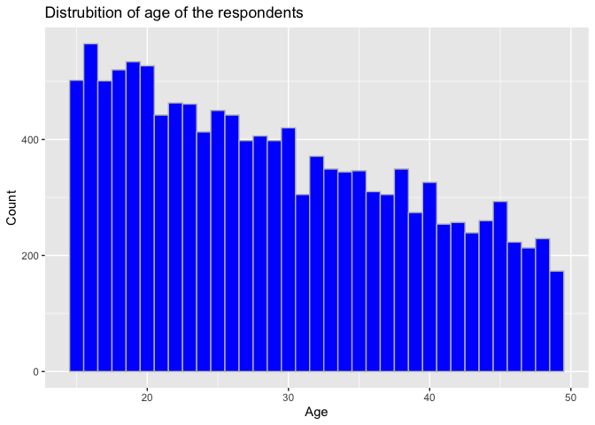

The majority of respondents were sexually active, with the youngest being 15 years old, and the number of respondents showed a decreasing trend with increasing age.

### Figure 2 : Distribution of education level of the respondents

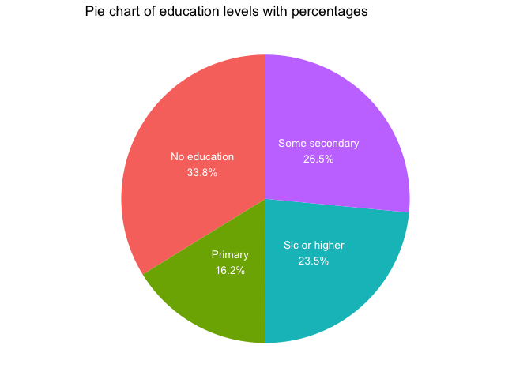

## Symptom description in different age groups

### Table 1: Distribition of genital sypmtoms in different age groups

| Age Group | STI in last 12 months No (%) | STI in last 12 months Yes (%) | Genital sore/ulcer in last 12 months No (%) | Genital sore/ulcer in last 12 months Yes (%) | Genital discharge in last 12 months No (%) | Genital discharge in last 12 months Yes (%) |
| --- | --- | --- | --- | --- | --- | --- |
| 15-19 | 99.92 | 0.08 | 99.24 | 0.76 | 96.15 | 3.85 |
| 20-24 | 99.70 | 0.30 | 97.92 | 2.04 | 88.94 | 11.06 |
| 25-29 | 99.47 | 0.53 | 98.04 | 1.96 | 87.15 | 12.80 |
| 30-34 | 99.33 | 0.67 | 96.93 | 3.02 | 85.97 | 14.03 |
| 35-39 | 99.49 | 0.51 | 97.35 | 2.53 | 86.62 | 13.32 |
| 40-44 | 99.40 | 0.60 | 97.98 | 2.02 | 88.77 | 11.23 |
| 45-49 | 99.82 | 0.18 | 98.14 | 1.77 | 89.12 | 10.88 |

This table presents the distribution of STI presence, genital sore or ulcer, and genital discharge among participants in the last 12 months by age group. The most frequently reported symptom was genital discharge, with the highest number observed in women aged 30–34 years (14.03%). This was followed by genital sores or ulcers, which also peaked in the 30–34 age group(3.02%), while self-reported STI diagnosis was less common overall but most frequently reported by women in the same age range(0.67%).

### Figure 1 : STI and relation with last partner

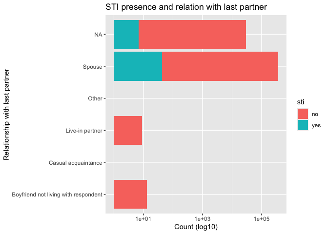

### Figure 2 : Genital sore / ulcer and relation with last partner

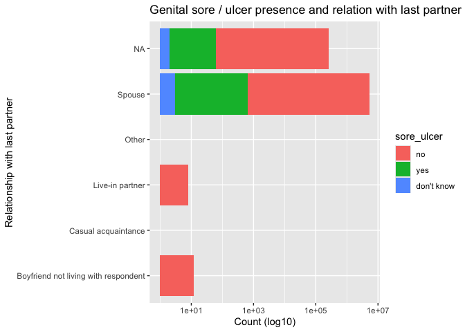

### Figure 3 : Genital discharge and relation with last partner

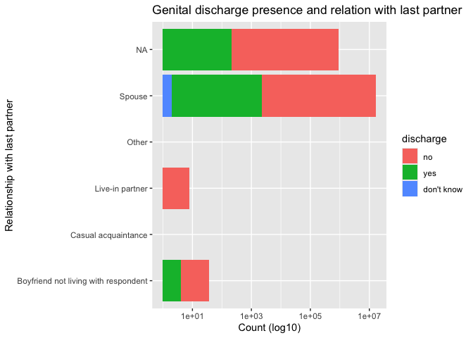

This bar charts illustrate the frequency of participants’ relationship status with their last partner. The most common category was spouse, followed by the NA group—which was the second most frequent—then boyfriend not living with the respondent, and live-in partner.

In terms of STI presence, it was reported only among participants whose last partner was a spouse or in the NA group.

A second bar chart shows the distribution of genital sore/ulcer presence by relationship status, with cases reported exclusively among those whose last partner was a spouse or in the NA group.

Similarly, the third bar chart presents genital discharge presence by partner type, with symptoms reported among participants whose last partner was a spouse, in the NA group, and also among those whose last partner was a boyfriend not living with the respondent.